# Transit App Usage and Bus Occupancy: Comparing Off-Campus (A) and On-Campus (B) Routes

Matthew Morris

9/30/2026

# 1. Introduction

Buses track how many Transit App users are aboard at any moment. Observers (from a team of student volunteers, and myself) also record how full the bus actually is. This report asks three questions:

1. Is there a statistically significant relationship between the number of reported Transit App users and the actual occupancy of a bus?
2. Do **Group A** routes (25, 26; Junior/Senior, off-campus) differ from **Group B** routes (30, 31, 33; on-campus, residence halls and classes; Freshmen/Sophomores)?
3. **Hypothesis:** Group A buses will have fewer Transit App users per person actually on the bus (i.e., lower Transit App usage among their riders).

# 2. Data and methods

## 2.1 Data collection

The number of Transit App users aboard is tracked by the bus before the observer boards. Seats taken is the observer’s headcount of people aboard, minus people waiting for the bus with the observer, expressed as a fraction of that bus type’s capacity (1 = full).

```r
buses <- read_csv(
"route,group,transit_app_users,seats
26,A,2,0.4
26,A,3,0.5
26,A,7,1
26,A,2,0.3
26,A,2,0.45
25,A,3,0.5
25,A,5,0.71
25,A,2,0.43
26,A,3,0.45
26,A,7,1
26,A,2,0.31
26,A,2,0.45
25,A,3,0.5
25,A,4,0.66
30,B,5,0.44
30,B,4,0.35
30,B,4,0.33
30,B,6,0.64
30,B,2,0.46
30,B,1,0.14
31,B,9,0.53
31,B,11,0.61
31,B,7,0.55
31,B,2,0.2
31,B,3,0.23
31,B,4,0.34
31,B,6,0.52
31,B,2,0.39
33,B,4,0.43
33,B,6,0.54
33,B,7,0.66
33,B,6,0.81
33,B,9,1
33,B,5,0.44
33,B,4,0.31") %>%
  mutate(route = factor(route),
         group = factor(group),
         # Transit App users per unit of occupancy (higher = more Transit App users per full bus)
         users_per_fullness = transit_app_users / seats)

buses %>%
  group_by(group) %>%
  summarise(trips = n(),
            routes = n_distinct(route),
            mean_transit_app_users = mean(transit_app_users),
            sd_transit_app_users = sd(transit_app_users),
            mean_seats = mean(seats),
            sd_seats = sd(seats),
            mean_users_per_fullness = mean(users_per_fullness)) %>%
  kable(digits = 2, caption = "Summary by group")
```

Summary by group

| group | trips | routes | mean_transit_app_users | sd_transit_app_users | mean_seats | sd_seats | mean_users_per_fullness |
| --- | --- | --- | --- | --- | --- | --- | --- |
| A | 14 | 2 | 3.36 | 1.78 | 0.55 | 0.22 | 5.96 |
| B | 21 | 3 | 5.10 | 2.57 | 0.47 | 0.20 | 10.79 |

## 2.2 Statistical methods

All analyses were done in R (R version 4.6.1 (2026-06-24 ucrt)).

# 3. Results

## 3.1 Transit App users and actual occupancy

```r
cor.test(~ transit_app_users + seats, data = buses)                       # Pearson
```

```
##
##  Pearson's product-moment correlation
##
## data:  transit_app_users and seats
## t = 5.3152, df = 33, p-value = 7.278e-06
## alternative hypothesis: true correlation is not equal to 0
## 95 percent confidence interval:
##  0.4470805 0.8255494
## sample estimates:
##       cor
## 0.6791429
```

```r
cor.test(~ transit_app_users + seats, data = buses,
         method = "spearman", exact = FALSE)                      # Spearman
```

```
##
##  Spearman's rank correlation rho
##
## data:  transit_app_users and seats
## S = 1966.3, p-value = 8.576e-07
## alternative hypothesis: true rho is not equal to 0
## sample estimates:
##      rho
## 0.724607
```

```r
m1 <- lm(seats ~ transit_app_users, data = buses)
summary(m1)
```

```
##
## Call:
## lm(formula = seats ~ transit_app_users, data = buses)
##
## Residuals:
##      Min       1Q   Median       3Q      Max
## -0.28310 -0.11742  0.00376  0.08522  0.34376
##
## Coefficients:
##                   Estimate Std. Error t value Pr(>|t|)
## (Intercept)        0.24175    0.05573   4.337 0.000128 ***
## transit_app_users  0.05921    0.01114   5.315 7.28e-06 ***
## ---
## Signif. codes:  0 '***' 0.001 '**' 0.01 '*' 0.05 '.' 0.1 ' ' 1
##
## Residual standard error: 0.1569 on 33 degrees of freedom
## Multiple R-squared:  0.4612, Adjusted R-squared:  0.4449
## F-statistic: 28.25 on 1 and 33 DF,  p-value: 7.278e-06
```

```r
confint(m1)
```

```
##                        2.5 %     97.5 %
## (Intercept)       0.12835330 0.35513749
## transit_app_users 0.03654824 0.08187918
```

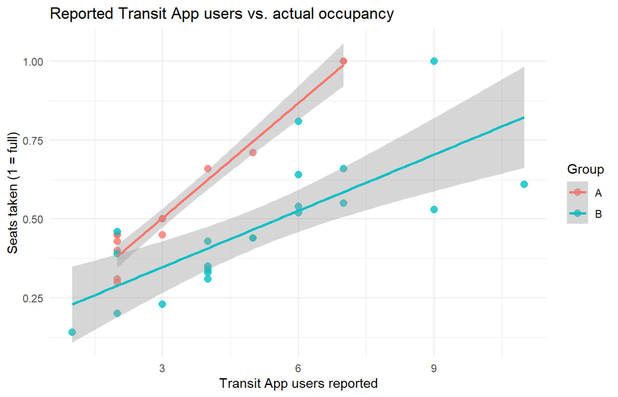

```r
ggplot(buses, aes(transit_app_users, seats, colour = group)) +
  geom_point(size = 2.5, alpha = 0.8) +
  geom_smooth(method = "lm", se = TRUE) +
  labs(x = "Transit App users reported", y = "Seats taken (1 = full)",
       colour = "Group",
       title = "Reported Transit App users vs. actual occupancy") +
  theme_minimal()
```

**Interpretation.** There is a significant positive relationship (Pearson r = 0.68, p < 0.001; Spearman rho = 0.72, p < 0.001). Each additional Transit App user corresponds to roughly 0.06 more of the bus filled (R-squared about 0.46, so reported Transit App users explain less than half of the variation in occupancy). The relationship also holds within each group separately.

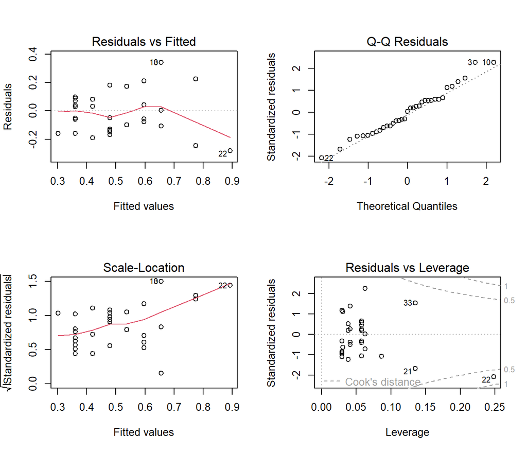

```r
par(mfrow = c(2, 2)); plot(m1); par(mfrow = c(1, 1))
```

## 3.2 Group A vs. Group B

```r
shapiro.test(buses$transit_app_users[buses$group == "A"])
```

```
##
##  Shapiro-Wilk normality test
##
## data:  buses$transit_app_users[buses$group == "A"]
## W = 0.75535, p-value = 0.001474
```

```r
shapiro.test(buses$transit_app_users[buses$group == "B"])
```

```
##
##  Shapiro-Wilk normality test
##
## data:  buses$transit_app_users[buses$group == "B"]
## W = 0.95496, p-value = 0.421
```

```r
leveneTest(seats ~ group, data = buses)
```

|  | Df | F value | Pr(>F) |
| --- | --- | --- | --- |
| group | 1 | 0.001303386 | 0.9714182 |
|  | 33 | NA | NA |

```r
cat("--- Seats taken ---\n")
```

```
## --- Seats taken ---
```

```r
t.test(seats ~ group, data = buses)
```

```
##
##  Welch Two Sample t-test
##
## data:  seats by group
## t = 1.0115, df = 26.29, p-value = 0.321
## alternative hypothesis: true difference in means between group A and group B is not equal to 0
## 95 percent confidence interval:
##  -0.07708228  0.22660609
## sample estimates:
## mean in group A mean in group B
##       0.5471429       0.4723810
```

```r
wilcox.test(seats ~ group, data = buses, exact = FALSE)
```

```
##
##  Wilcoxon rank sum test with continuity correction
##
## data:  seats by group
## W = 170.5, p-value = 0.4382
## alternative hypothesis: true location shift is not equal to 0
```

```r
cat("\n--- Transit App users ---\n")
```

```
##
## --- Transit App users ---
```

```r
t.test(transit_app_users ~ group, data = buses)
```

```
##
##  Welch Two Sample t-test
##
## data:  transit_app_users by group
## t = -2.3646, df = 32.912, p-value = 0.0241
## alternative hypothesis: true difference in means between group A and group B is not equal to 0
## 95 percent confidence interval:
##  -3.2336971 -0.2424933
## sample estimates:
## mean in group A mean in group B
##        3.357143        5.095238
```

```r
wilcox.test(transit_app_users ~ group, data = buses, exact = FALSE)
```

```
##
##  Wilcoxon rank sum test with continuity correction
##
## data:  transit_app_users by group
## W = 85.5, p-value = 0.03722
## alternative hypothesis: true location shift is not equal to 0
```

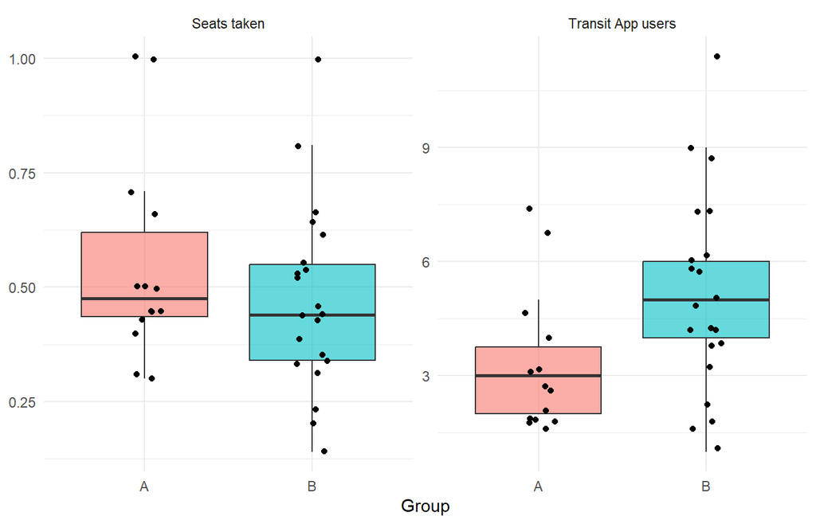

```r
plot_data <- buses %>%
  pivot_longer(c(transit_app_users, seats), names_to = "measure", values_to = "value") %>%
  mutate(measure = dplyr::recode(measure,
                                 transit_app_users = "Transit App users",
                                 seats = "Seats taken"))

ggplot(data = plot_data, mapping = aes(x = group, y = value, fill = group)) +
  geom_boxplot(alpha = 0.6, outlier.shape = NA) +
  geom_jitter(width = 0.1, size = 1.5) +
  facet_wrap(~ measure, scales = "free_y") +
  labs(x = "Group", y = NULL) +
  theme_minimal() +
  theme(legend.position = "none")
```

**Interpretation.** Seat occupancy does **not** differ significantly between groups (A mean 0.55 vs. B mean 0.47; Welch p = 0.32; Wilcoxon p = 0.44). Reported Transit App users **do** differ: B buses carry more Transit App users (A mean 3.4 vs. B mean 5.1; Welch p = 0.024; Wilcoxon p = 0.037). Buses in both groups are about equally full, but B buses have more Transit App users aboard.

## 3.3 Hypothesis: A has fewer Transit App users per person on the bus

```r
buses %>%
  group_by(group) %>%
  summarise(mean = mean(users_per_fullness),
            median = median(users_per_fullness)) %>%
  kable(digits = 2, caption = "Transit App users per unit of occupancy")
```

Transit App users per unit of occupancy

| group | mean | median |
| --- | --- | --- |
| A | 5.96 | 6.03 |
| B | 10.79 | 11.36 |

```r
t.test(users_per_fullness ~ group, data = buses, alternative = "less")        # A < B
```

```
##
##  Welch Two Sample t-test
##
## data:  users_per_fullness by group
## t = -6.3679, df = 24.784, p-value = 5.983e-07
## alternative hypothesis: true difference in means between group A and group B is less than 0
## 95 percent confidence interval:
##       -Inf -3.538039
## sample estimates:
## mean in group A mean in group B
##        5.959133       10.794710
```

```r
wilcox.test(users_per_fullness ~ group, data = buses,
            alternative = "less", exact = FALSE)
```

```
##
##  Wilcoxon rank sum test with continuity correction
##
## data:  users_per_fullness by group
## W = 24, p-value = 1.839e-05
## alternative hypothesis: true location shift is less than 0
```

```r
m2 <- lm(seats ~ transit_app_users * group, data = buses)
anova(m2)
```

|  | Df | Sum Sq | Mean Sq | F value | Pr(>F) |
| --- | --- | --- | --- | --- | --- |
| transit_app_users | 1 | 0.6956427 | 0.69564266 | 55.596106 | 2.122254e-08 |
| group | 1 | 0.3040863 | 0.30408635 | 24.302732 | 2.626356e-05 |
| transit_app_users:group | 1 | 0.1206026 | 0.12060265 | 9.638623 | 4.049520e-03 |
| Residuals | 31 | 0.3878855 | 0.01251244 | NA | NA |

```r
summary(m2)
```

```
##
## Call:
## lm(formula = seats ~ transit_app_users * group, data = buses)
##
## Residuals:
##       Min        1Q    Median        3Q       Max
## -0.213382 -0.069817 -0.003778  0.041222  0.295506
##
## Coefficients:
##                          Estimate Std. Error t value Pr(>|t|)
## (Intercept)               0.13951    0.06569   2.124  0.04177 *
## transit_app_users         0.12142    0.01742   6.969 8.07e-08 ***
## groupB                    0.02999    0.08588   0.349  0.72933
## transit_app_users:groupB -0.06198    0.01996  -3.105  0.00405 **
## ---
## Signif. codes:  0 '***' 0.001 '**' 0.01 '*' 0.05 '.' 0.1 ' ' 1
##
## Residual standard error: 0.1119 on 31 degrees of freedom
## Multiple R-squared:  0.7428, Adjusted R-squared:  0.7179
## F-statistic: 29.85 on 3 and 31 DF,  p-value: 2.861e-09
```

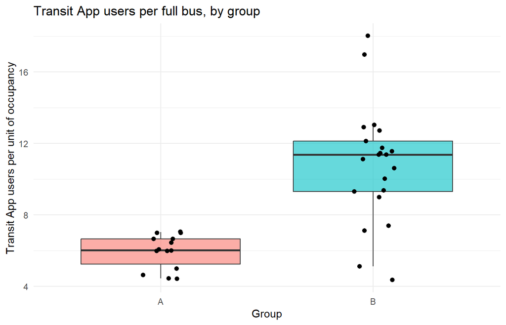

```r
ggplot(buses, aes(group, users_per_fullness, fill = group)) +
  geom_boxplot(alpha = 0.6, outlier.shape = NA) +
  geom_jitter(width = 0.1, size = 1.8) +
  labs(x = "Group", y = "Transit App users per unit of occupancy",
       title = "Transit App users per full bus, by group") +
  theme_minimal() + theme(legend.position = "none")
```

Group A has fewer Transit App users per unit of occupancy (about 6.0 vs. 10.8; one-sided Welch p < 0.001; one-sided Wilcoxon p < 0.001), which supports the hypothesis. The group × Transit App users interaction is also significant (p = 0.004): in A, each reported Transit App user corresponds to about 0.12 of a bus filled, versus about 0.06 in B. In other words, Transit App users make up a smaller share of riders on A routes.

# 4. Summary and Conclusions

The number of reported Transit App users is significantly associated with actual occupancy (r = 0.68, p < 0.001), but is an overall poor predictor (R² = 0.46).

Overall occupancy does not differ majorly between off-campus (A) and on-campus (B) routes, but Transit App users are a significantly smaller share of riders on A routes. This is consistent with the hypothesis that Junior/Senior riders on off-campus routes use the Transit App less than the mixed population of on-campus route riders.

Limitations exist due to the usage of the 25 and 26 routes in the A-group; While routes 31, 30, and 33 cover most major points of student traffic on-campus, most off-campus volunteers lived north of campus, and findings on other off-campus routes may add additional insight.